# Fitting multivariate Bayesian time series models

11 Feb 2021

## Overview of today’s material

- Using STAN for MAP estimation
- Multivariate time series models
- DFA models
- Writing our own Stan code

## MAP (maximum a posteriori) estimation

- Point estimate of unknown parameters
- Optimization algorithms: BFGS, Newton, etc
- Estimates similar to maximum likelihood, but also incorporate prior
- Quick for checking models, etc

## MAP estimation in Stan

- We left off with a Bayesian DLM with random walk in intercept

```r
bayes_fit = fit_stan(y = SalmonSurvCUI$logit.s,
               model_name="dlm-intercept")
```

## MAP estimation in Stan

- Switching this to MAP estimation

```r
map_fit = fit_stan(y = SalmonSurvCUI$logit.s,
               model_name="dlm-intercept", map_estimation=TRUE)
```

## MAP estimation in Stan

```r
print(map_fit)
```

[output not shown]

[output cut: 80 more lines]

[output not shown]

## MAP estimation in Stan

- Check that model converged

```r
map_fit$return_code
```

```
## [1] 0
```

- MAP value when converged

```r
map_fit$value
```

```
## [1] 595.6098
```

## MAP estimation in Stan

- grep or other string matching functions needed

```r
grep("pred",names(map_fit$par))
```

```
##  [1] 46 47 48 49 50 51 52 53 54 55 56 57 58 59 60 61 62 63 64 65 66 67 68 69 70
## [26] 71 72 73 74 75 76 77 78 79 80 81 82 83 84 85 86 87
```

```r
pred = map_fit$par[grep("pred",names(map_fit$par))]
```

## MAP estimation in Stan

- grep or other string matching functions needed

```r
grep("pred",names(map_fit$par))
```

```
##  [1] 46 47 48 49 50 51 52 53 54 55 56 57 58 59 60 61 62 63 64 65 66 67 68 69 70
## [26] 71 72 73 74 75 76 77 78 79 80 81 82 83 84 85 86 87
```

```r
pred = map_fit$par[grep("pred",names(map_fit$par))]
```

## MAP estimation in Stan

- grep or other string matching functions needed

```r
grep("pred",names(map_fit$par))
```

```
##  [1] 46 47 48 49 50 51 52 53 54 55 56 57 58 59 60 61 62 63 64 65 66 67 68 69 70
## [26] 71 72 73 74 75 76 77 78 79 80 81 82 83 84 85 86 87
```

```r
pred = map_fit$par[grep("pred",names(map_fit$par))]
```

## MAP estimation in Stan

- include SEs of estimates, via Hessian

```r
map_fit = fit_stan(y = SalmonSurvCUI$logit.s,
     model_name="dlm-intercept",
     map_estimation=TRUE,
     hessian=TRUE)
```

- or change algorithm (“LBFGS” default) to “BFGS” or “Newton”

```r
map_fit = fit_stan(y = SalmonSurvCUI$logit.s,
     model_name="dlm-intercept",
     map_estimation=TRUE,
     hessian=TRUE,
     algorithm="BFGS")
```

## MAP estimation in Stan

- Posterior means, 95% CIs

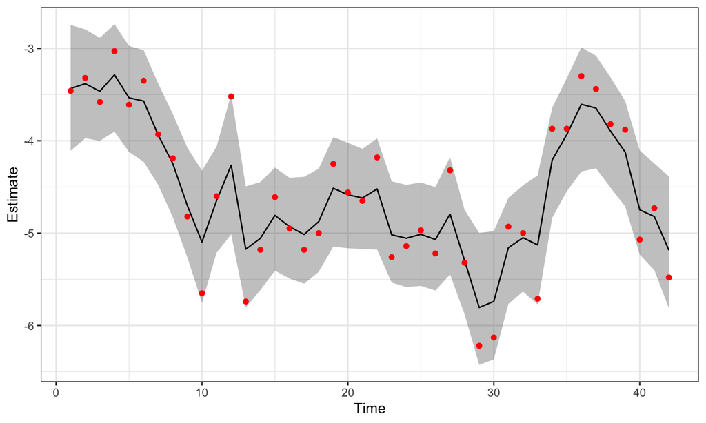

## MAP estimation in Stan

- MAP estimates = posterior

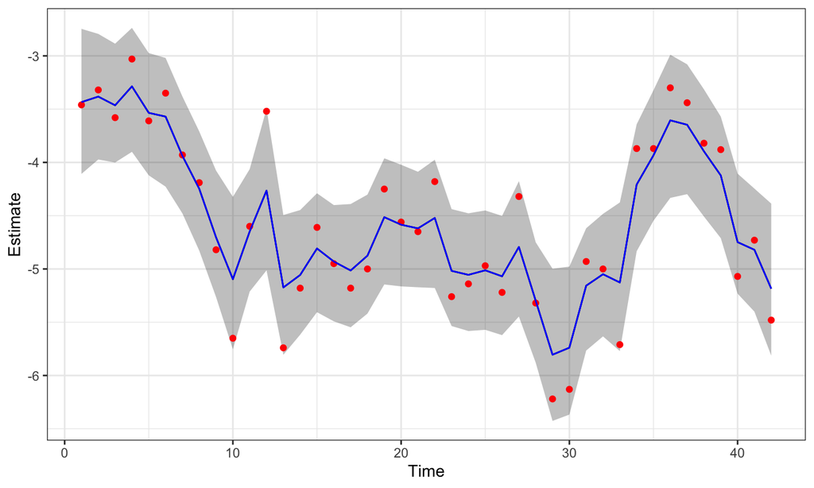

## Multivariate time series models

- Multivariate state space models
- Stan package for fitting models similar to MARSS

```r
devtools::install_github("nwfsc-timeseries/tvvarss")
```

## Multivariate time series models

- Most models in tvvarss() are exactly the same as MARSS
- Takes in data matrix y
- `family` argument defaults to Gaussian, but can be many others

```r
tvvarss::tvvarss(y = y, family = "poisson",...)
```

## Multivariate time series models

- Like MARSS, variances can be shared (default) or unique by species, or time series

```r
tvvarss::tvvarss(y = y, shared_r = R, shared_q = Q,...)
```

## Multivariate time series models

- Optional ‘process’ argument acts as `Z` in MARSS and maps time series to latent state processes

```r
tvvarss::tvvarss(y = y, shared_r = R, shared_q = Q,...)
```

## Multivariate time series models

- Perhaps most exciting feature is time-varying interactions (AR coefficients)
- Time-varying vector autoregressive models
- AR coefficients behave like a DLM

```r
tvvarss::tvvarss(y = y, dynamicB = TRUE,...)
```

- Time-varying parameters are data hungry! We’ll dive into this more later in the quarter

## Bayesian DFA models

- DFA models from `atsar` bundled with other DFA code we’ve developed

```r
devtools::install_github("fate-ewi/bayesdfa")
```

## Bayesian DFA models

- DFA poses interesting identifiability challenges
- Bayesian models generally involve > 1 MCMC chain
- Direction of DFA loadings / trends don’t have meaning

## Bayesian DFA models

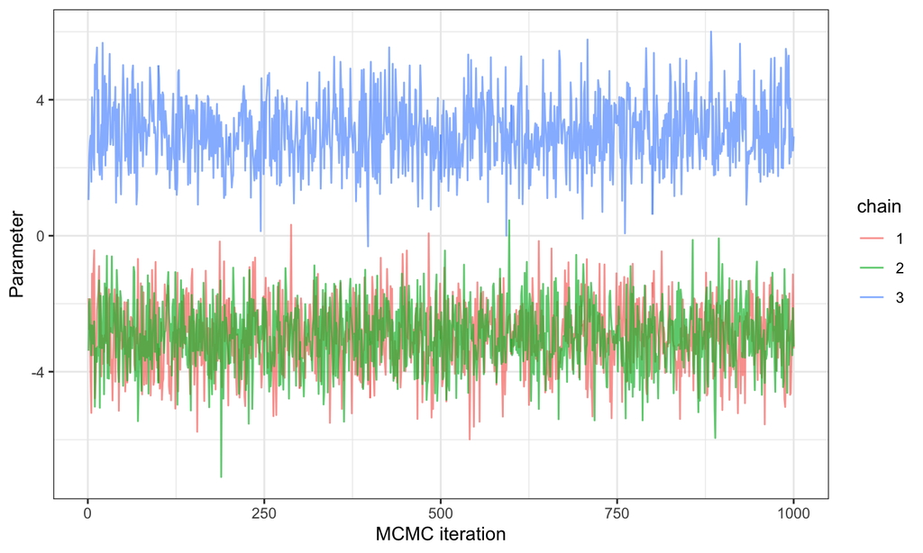

## Bayesian DFA models

- Solution 1: priors for identifiability
- Solution 2: post-hoc ‘chain flipping’ before convergence tests run

## Bayesian DFA models

- Fitting DFA models will give very similar answers to using MARSS

```r
data("harborSealWA")
```

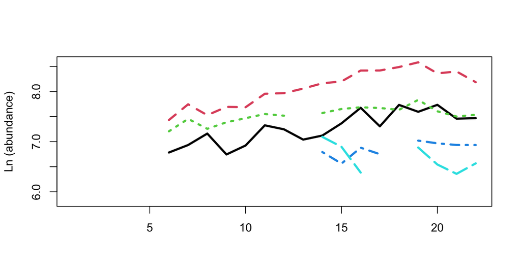

## Bayesian DFA models

We’ll extract predictions from the best model,

```r
fit = bayesdfa::fit_dfa(y = t(harborSealWA[,-1]), num_trends = 1)
```

And as an `stanfit` object, we can extract summaries of states `x`

```r
pars = extract(fit$model)
```

## Bayesian DFA models

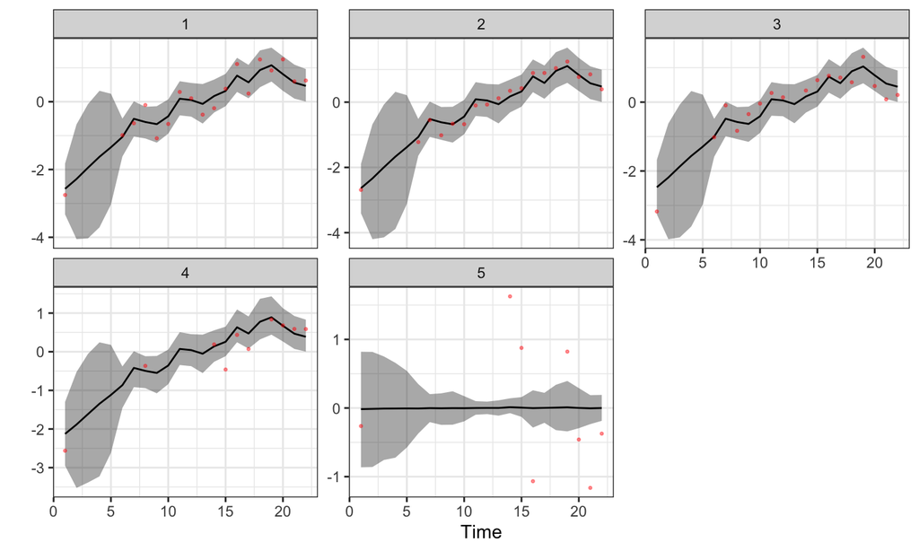

```r
bayesdfa::plot_fitted(fit) + theme_bw()
```

## Bayesian DFA models

- DFA extension 1: long format data (optional), replicate observations

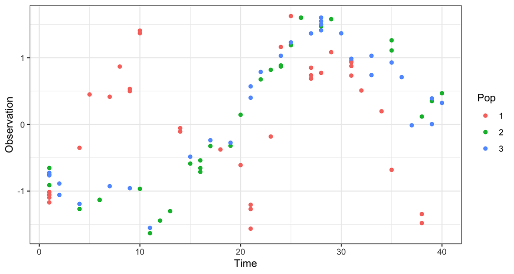

## Bayesian DFA models

- DFA extension 2: temporal extremes

\[x_{t}=x_{t-1}+\delta_{t-1}\] \[\delta_{t-1} \sim Normal(0,q)\]

- But do these deviations have to be normal? NO!

\[\delta_{t-1} \sim Student-t(\nu,0,q)\]

## Bayesian DFA models

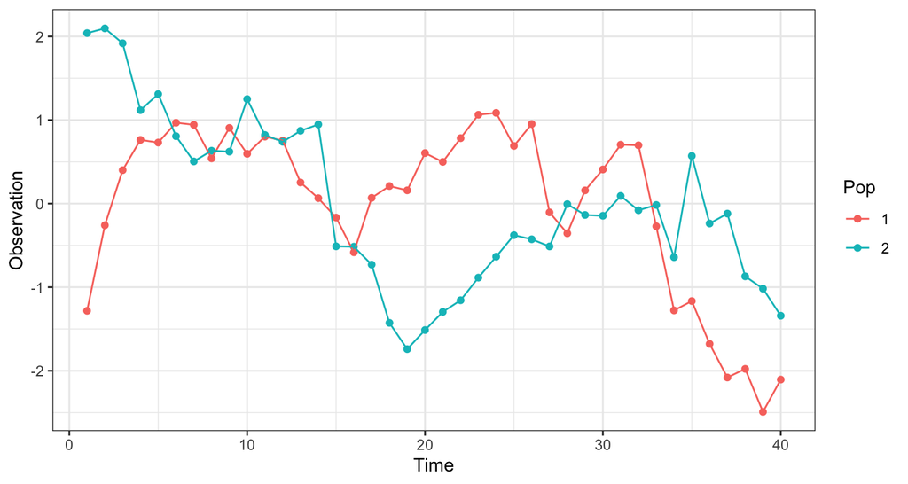

## Bayesian DFA models

- Extremes example: coho salmon body size in coastal fisheries

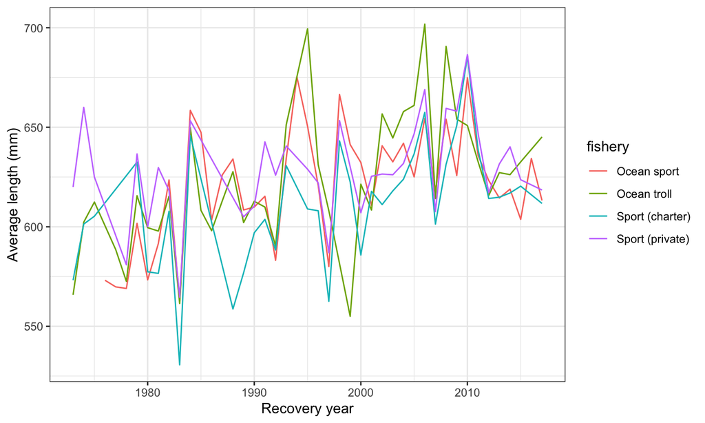

## Bayesian DFA models

- Fitting the model

```r
coho = readRDS("coho_mean_length.rds")
# rename variables
coho=dplyr::rename(coho, obs=mean_length,time=recovery_year,ts=fishery)
fit = fit_dfa(y = coho, data_shape="long",estimate_nu = TRUE)
```

## Bayesian DFA models

- Let’s look at df parameter, \(\nu\)
- Mean ~ 19.5, median ~ 16.3

```r
pars = extract(fit$model)
```

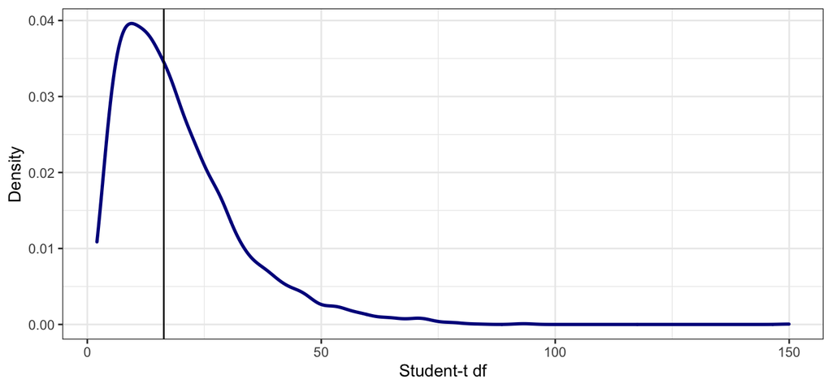

## Bayesian DFA models

- \(\nu\) parameter ranges from 2 (heavy tails) to normal (30)

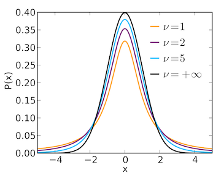

(source: Wikipedia)

## Bayesian DFA models

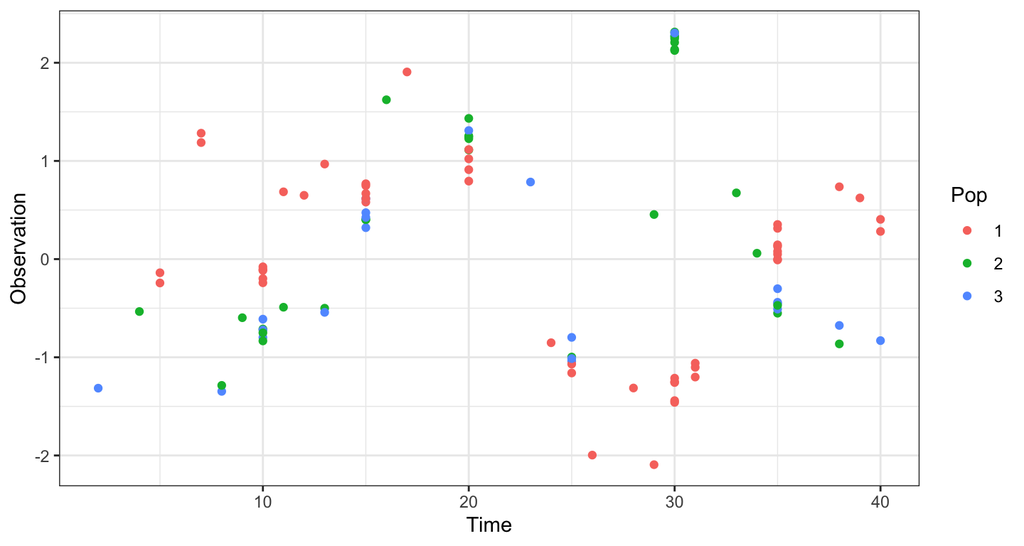

## Bayesian DFA models

- AR models (conventional DFA) may not be well suited
- Alternative approach: use Gaussian Process models to model smooth trends
- Feddern et al. 2021 (Global Change Biology)

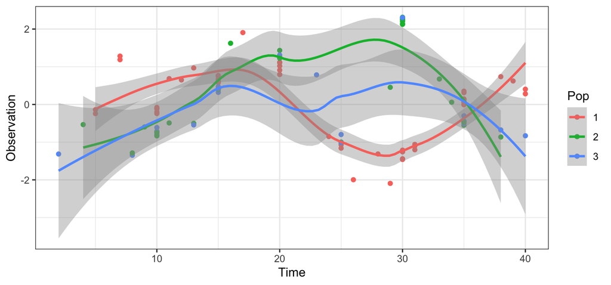

## Bayesian DFA models

- What’s a Gaussian Process model?
- Instead of modeling process \[x_{t} = x_{t-1}...\]
- We model the covariance of the \(\textbf{x}\)
- But there are a lot of \(\textbf{x}\)!!

## Bayesian DFA models

- Example: Gaussian covariance (aka ‘squared exponential’)

\[\Sigma_{t,t+3} = \sigma^2exp(\frac{(t-(t+3))^2}{2\tau^2})\]

- \(\sigma^2\) controls variability
- \(\tau\) controls how quickly covariance decays between points

## Bayesian DFA models

- Implementation

```r
fit_dfa(y= y, num_trends = 2, ..., trend_model = c("gp"))
```

## Bayesian DFA models

- DFA extension 3: alternate constraints on loadings matrix
- Conventional constraints on loadings matrix

```
##             [,1]       [,2]       [,3]
## [1,] -0.56047565  0.0000000  0.0000000
## [2,] -0.23017749  0.4609162  0.0000000
## [3,]  1.55870831 -1.2650612  0.4007715
## [4,]  0.07050839 -0.6868529  0.1106827
## [5,]  0.12928774 -0.4456620 -0.5558411
```

## Bayesian DFA models

- Alternative: compositional DFA model

```
##           [,1]       [,2]       [,3]
## [1,] 0.6871757 0.24516978 0.06765452
## [2,] 0.1491745 0.06014499 0.79068047
## [3,] 0.3885419 0.59306319 0.01839489
## [4,] 0.2919682 0.30545457 0.40257721
## [5,] 0.3760087 0.33262301 0.29136825
```

## Bayesian DFA models

- Under compositional DFA model, time series are true mixtures of underlying trends

\[\textbf{Y} = \textbf{Zx}\]

```r
fit_dfa(y = y, num_trends = 2, ..., z_model = "proportion")
```

- When might this be useful?
- Stable isotope data, environmental monitoring, pollutant data, etc

## Writing our own Stan scripts

- Stan scripts always start with a data block
- Data needs to be typed

```r
data {
  int<lower=0> N;
  int<lower=0> K;
  real y[N];
  int P;
  int y_int[N];
  matrix[N, K] x;
}
```

- [Stan manual](https://mc-stan.org/docs/2_26/reference-manual/index.html)

## Writing our own Stan scripts

- transformed data block is optional

```r
transformed data {
  int zeros[N];
  for(i in 1:N) {
    zeros[i] = 0;
  }
}
```

## Writing our own Stan scripts

- parameters block containts any parameters

```r
parameters {
  real x0;
  vector[K] beta0;
  vector[K] pro_dev[N-1];
  real<lower=0> sigma_process[K];
  real<lower=0> sigma_obs;
}
```

## Writing our own Stan scripts

- parameters block containts any parameters

```r
parameters {
  real x0;
  vector[K] beta0;
  vector[K] pro_dev[N-1];
  real<lower=0> sigma_process[K];
  real<lower=0> sigma_obs;
}
```

## Writing our own Stan scripts

- transformed parameters block contains derived quantities
- examples: predicted states for state space time series model

```r
transformed parameters {
  vector[N] pred;
  pred[1] = x0;
  for(i in 2:N) {
    pred[i] = phi*pred[i-1] + sigma_process*pro_dev[i-1];
  }
}
```

## Writing our own Stan scripts

- model block contains priors on parameters
- likelihood (or data model)

```r
model {
  x0 ~ normal(0,10);
  phi ~ normal(0,1);
  sigma_process ~ student_t(3,0,2);
  sigma_obs ~ student_t(3,0,2);
  pro_dev ~ std_normal();
  for(i in 1:N) {
    y[i] ~ normal(pred[i], sigma_obs);
  }
}
```

## Writing our own Stan scripts

- generated data block (optional)
- includes quantities useful for model selection, prediction, forecasts, etc

```r
generated quantities {
  vector[N] log_lik;
  for (n in 1:N) log_lik[n] = normal_lpdf(y[n] | pred[n], sigma_obs);
}
```

## Writing our own Stan scripts

- Ok – let’s do this in practice
- Problem # 1: let’s take our state space random walk model and modify it to better handle extreme events with the Student - t distribution
- Mathematically

\[\delta_{t-1} \sim Normal(0,q)\] becomes

\[\delta_{t-1} \sim Student-t(\nu,0,q)\]

## Writing our own Stan scripts

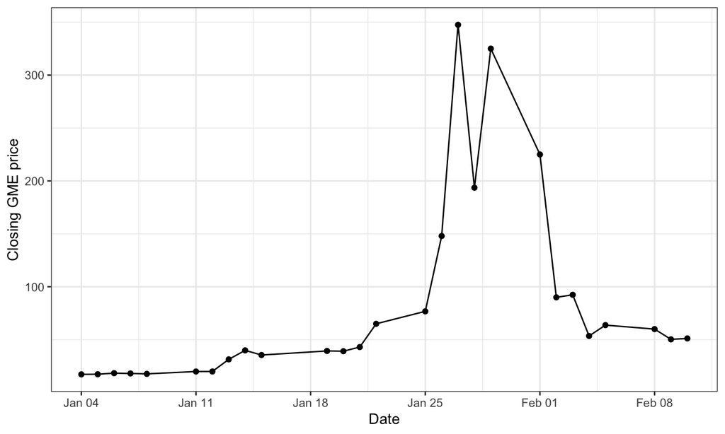

## Writing our own Stan scripts

- You could do this in RStudio (File -> New File -> Stan File)
- Scripts for the `atsar` package linked below

https://github.com/nwfsc-timeseries/atsar/tree/master/inst/stan

- We’re just going to modify this code (ss_ar.stan) rather than start from scratch

## Writing our own Stan scripts

- 2 things need to change
- Change process error deviations from Normal to Student-t distribution
- Add \(\nu\) as a parameter, with constraints (> 2)

## Writing our own Stan scripts

```r
parameters {
real<lower=2> nu;
...
}
```

## Writing our own Stan scripts

```r
model{
...
nu ~ student_t(3, 2, 3);
pro_dev ~ student_t(nu, 0, 1);
//pro_dev ~ std_normal();
...
}
```

## Writing our own Stan scripts

- Done! Now we can fit the model

```r
y = gme$Close
N = length(y)
n_pos = length(which(!is.na(y)))
pos_indx = c(which(!is.na(y)),0,0)

fit = stan(file = "ss_ar_t.stan",
  data = list(y = y, N = N, n_pos = n_pos, pos_indx = pos_indx))
```

## Writing our own Stan scripts

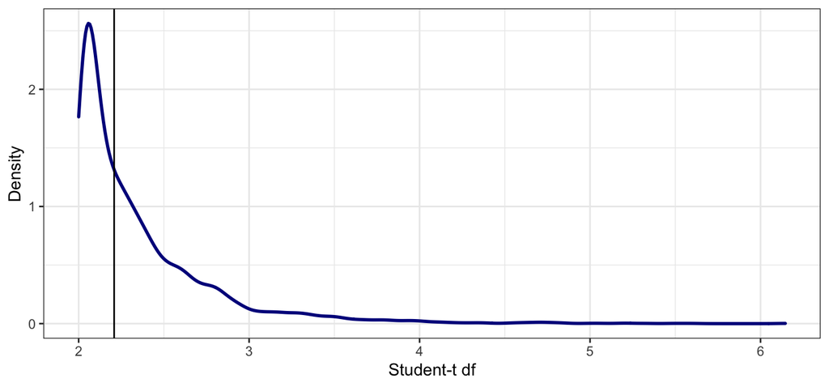